# Table of Contents

**VEHICLE TYPE PREDICTION USING VEHICLE SILHOUETTES**

**GROUP DETAILS**

**GROUP NAME:** Group 99

**GROUP MEMBERS:**

1. VIJAY CHALAMALA -- S3817359
2. VISHAL PATNAIK DAMODARAPATRUNI -- S3811521
3. SRI VENKATA MANIDEEPU MADDIPATI -- S3820822

# INTRODUCTION

The aim is to predict the type of vehicle by fitting and comparing different machine learning algorithms on Vehicle Silhouettes data which contains the measurements of different vehicles such as model cars, vans, and buses. The dataset is taken from OpenML repository at https://www.openml.org/d/54(Vanschoren, 2021). This data is cleaned using pre-processing techniques in Phase 1 and the resulted data is taken here for further analysis. It contains one target variable and 18 descriptive numerical features.

## Report Overview

This report contains different sections such as,

1. **Overview of Methodology:** Provides a brief information about the Methodology.
2. **Model Pre-processing:** This section contains, the data preparation steps to fit the model.
3. **Feature Selection:** Explains how the important features are selected from the data.
4. **Model Fitting and Tuning:** Explains model fitting and hyperparameter tuning process for each model.
5. **Model Comparison:** Comparing and analysing the results of each model.
6. **Critique & Limitations:** Explains overall findings and stating the limitations from it.
7. **Summary & Conclusions:** Brief wrap-up of project.

## Overview of Methodology

We consider below classification models to predict the class as the target feature is categorical variable,

1. K- Nearest Neighbor (KNN)
2. Gaussian Naive Bayes (NB)
3. Support Vector Classifier (SVC)
4. Decision Tree (DT)
5. Logistic Regression

Further, the best parameters are selected among multiple values to fit the model. Using these parameters, the models are fitted on test data using 10-fold cross validation. Finally, the result of each model is analysed and compared with other models to predict the best model.

# Model Pre-processing

**Importing Packages**

```python
import pandas as pd
import numpy as np
import matplotlib.pyplot as plt
import seaborn as sns
import itertools

import warnings
warnings.filterwarnings("ignore")

import matplotlib.pyplot as plt
%matplotlib inline
```

**Importing the preprocessed data from Phase 1**

```python
vehicle = pd.read_csv("Group_99.csv", encoding = "unicode_escape")# Loading the data using pandas function.
print(vehicle.shape)# gives the dimentions of the data frame.
vehicle# Displays the data in the data frame.
```

```
(846, 19)
```

|  | COMPACTNESS | CIRCULARITY | DISTANCE_CIRCULARITY | RADIUS_RATIO | PR.AXIS_ASPECT_RATIO | MAX.LENGTH_ASPECT_RATIO | SCATTER_RATIO | ELONGATEDNESS | PR.AXIS_RECTANGULARITY | MAX.LENGTH_RECTANGULARITY | SCALED_VARIANCE_MAJOR | SCALED_VARIANCE_MINOR | SCALED_RADIUS_OF_GYRATION | SKEWNESS_ABOUT_MAJOR | SKEWNESS_ABOUT_MINOR | KURTOSIS_ABOUT_MAJOR | KURTOSIS_ABOUT_MINOR | HOLLOWS_RATIO | Class |
| --- | --- | --- | --- | --- | --- | --- | --- | --- | --- | --- | --- | --- | --- | --- | --- | --- | --- | --- | --- |
| 0 | 95.0 | 48.0 | 83.0 | 178.0 | 72.000000 | 10.000000 | 162.0 | 42.0 | 20.0 | 159.0 | 176.0 | 379.0 | 184.0 | 70.000000 | 6.0 | 16.0 | 187.0 | 197.0 | VAN |
| 1 | 91.0 | 41.0 | 84.0 | 141.0 | 57.000000 | 9.000000 | 149.0 | 45.0 | 19.0 | 143.0 | 170.0 | 330.0 | 158.0 | 72.000000 | 9.0 | 14.0 | 189.0 | 199.0 | VAN |
| 2 | 104.0 | 50.0 | 106.0 | 209.0 | 66.000000 | 10.000000 | 207.0 | 32.0 | 23.0 | 158.0 | 223.0 | 635.0 | 220.0 | 73.000000 | 14.0 | 9.0 | 188.0 | 196.0 | SAAB |
| 3 | 93.0 | 41.0 | 82.0 | 159.0 | 63.000000 | 9.000000 | 144.0 | 46.0 | 19.0 | 143.0 | 160.0 | 309.0 | 127.0 | 63.000000 | 6.0 | 10.0 | 199.0 | 207.0 | VAN |
| 4 | 85.0 | 44.0 | 70.0 | 205.0 | 61.693853 | 8.567376 | 149.0 | 45.0 | 19.0 | 144.0 | 241.0 | 325.0 | 188.0 | 72.462175 | 9.0 | 11.0 | 180.0 | 183.0 | BUS |
| ... | ... | ... | ... | ... | ... | ... | ... | ... | ... | ... | ... | ... | ... | ... | ... | ... | ... | ... | ... |
| 841 | 93.0 | 39.0 | 87.0 | 183.0 | 64.000000 | 8.000000 | 169.0 | 40.0 | 20.0 | 134.0 | 200.0 | 422.0 | 149.0 | 72.000000 | 7.0 | 25.0 | 188.0 | 195.0 | SAAB |
| 842 | 89.0 | 46.0 | 84.0 | 163.0 | 66.000000 | 11.000000 | 159.0 | 43.0 | 20.0 | 159.0 | 173.0 | 368.0 | 176.0 | 72.000000 | 1.0 | 20.0 | 186.0 | 197.0 | VAN |
| 843 | 106.0 | 54.0 | 101.0 | 222.0 | 67.000000 | 12.000000 | 222.0 | 30.0 | 25.0 | 173.0 | 228.0 | 721.0 | 200.0 | 70.000000 | 3.0 | 4.0 | 187.0 | 201.0 | SAAB |
| 844 | 86.0 | 36.0 | 78.0 | 146.0 | 58.000000 | 7.000000 | 135.0 | 50.0 | 18.0 | 124.0 | 155.0 | 270.0 | 148.0 | 66.000000 | 0.0 | 25.0 | 190.0 | 195.0 | SAAB |
| 845 | 85.0 | 36.0 | 66.0 | 123.0 | 55.000000 | 5.000000 | 120.0 | 56.0 | 17.0 | 128.0 | 140.0 | 212.0 | 131.0 | 73.000000 | 1.0 | 18.0 | 186.0 | 190.0 | VAN |

846 rows × 19 columns

**Checking the null values**

```python
vehicle.isnull().sum()
```

```
COMPACTNESS                  0
CIRCULARITY                  0
DISTANCE_CIRCULARITY         0
RADIUS_RATIO                 0
PR.AXIS_ASPECT_RATIO         0
MAX.LENGTH_ASPECT_RATIO      0
SCATTER_RATIO                0
ELONGATEDNESS                0
PR.AXIS_RECTANGULARITY       0
MAX.LENGTH_RECTANGULARITY    0
SCALED_VARIANCE_MAJOR        0
SCALED_VARIANCE_MINOR        0
SCALED_RADIUS_OF_GYRATION    0
SKEWNESS_ABOUT_MAJOR         0
SKEWNESS_ABOUT_MINOR         0
KURTOSIS_ABOUT_MAJOR         0
KURTOSIS_ABOUT_MINOR         0
HOLLOWS_RATIO                0
Class                        0
dtype: int64
```

```python
vehicle.describe(include = 'all')
```

|  | COMPACTNESS | CIRCULARITY | DISTANCE_CIRCULARITY | RADIUS_RATIO | PR.AXIS_ASPECT_RATIO | MAX.LENGTH_ASPECT_RATIO | SCATTER_RATIO | ELONGATEDNESS | PR.AXIS_RECTANGULARITY | MAX.LENGTH_RECTANGULARITY | SCALED_VARIANCE_MAJOR | SCALED_VARIANCE_MINOR | SCALED_RADIUS_OF_GYRATION | SKEWNESS_ABOUT_MAJOR | SKEWNESS_ABOUT_MINOR | KURTOSIS_ABOUT_MAJOR | KURTOSIS_ABOUT_MINOR | HOLLOWS_RATIO | Class |
| --- | --- | --- | --- | --- | --- | --- | --- | --- | --- | --- | --- | --- | --- | --- | --- | --- | --- | --- | --- |
| count | 846.000000 | 846.000000 | 846.000000 | 846.000000 | 846.000000 | 846.000000 | 846.000000 | 846.000000 | 846.000000 | 846.000000 | 846.000000 | 846.000000 | 846.00000 | 846.000000 | 846.000000 | 846.000000 | 846.000000 | 846.000000 | 846 |
| unique | NaN | NaN | NaN | NaN | NaN | NaN | NaN | NaN | NaN | NaN | NaN | NaN | NaN | NaN | NaN | NaN | NaN | NaN | 4 |
| top | NaN | NaN | NaN | NaN | NaN | NaN | NaN | NaN | NaN | NaN | NaN | NaN | NaN | NaN | NaN | NaN | NaN | NaN | BUS |
| freq | NaN | NaN | NaN | NaN | NaN | NaN | NaN | NaN | NaN | NaN | NaN | NaN | NaN | NaN | NaN | NaN | NaN | NaN | 218 |
| mean | 93.678487 | 44.861702 | 82.088652 | 168.404046 | 61.177956 | 8.126922 | 168.839243 | 40.933806 | 20.582742 | 147.998818 | 188.470006 | 438.568348 | 174.70331 | 71.979826 | 6.168469 | 12.565720 | 188.932624 | 195.632388 | NaN |
| std | 8.234474 | 6.169866 | 15.771533 | 32.222517 | 5.623709 | 2.064796 | 33.244978 | 7.811560 | 2.592138 | 14.515652 | 31.067449 | 174.511867 | 32.54649 | 6.182516 | 4.589891 | 8.877577 | 6.163949 | 7.438797 | NaN |
| min | 73.000000 | 33.000000 | 40.000000 | 104.000000 | 47.000000 | 3.000000 | 112.000000 | 26.000000 | 17.000000 | 118.000000 | 130.000000 | 184.000000 | 109.00000 | 59.000000 | 0.000000 | 0.000000 | 176.000000 | 181.000000 | NaN |
| 25% | 87.000000 | 40.000000 | 70.000000 | 141.000000 | 57.000000 | 7.000000 | 146.250000 | 33.000000 | 19.000000 | 137.000000 | 167.000000 | 318.250000 | 149.00000 | 67.000000 | 2.000000 | 5.000000 | 184.000000 | 190.250000 | NaN |
| 50% | 93.000000 | 44.000000 | 80.000000 | 167.000000 | 61.000000 | 8.000000 | 157.000000 | 43.000000 | 20.000000 | 146.000000 | 178.500000 | 364.000000 | 173.00000 | 71.500000 | 6.000000 | 11.000000 | 188.000000 | 197.000000 | NaN |
| 75% | 100.000000 | 49.000000 | 98.000000 | 195.000000 | 65.000000 | 10.000000 | 198.000000 | 46.000000 | 23.000000 | 159.000000 | 217.000000 | 586.000000 | 198.00000 | 75.000000 | 9.000000 | 19.000000 | 193.000000 | 201.000000 | NaN |
| max | 119.000000 | 59.000000 | 112.000000 | 252.000000 | 76.000000 | 13.000000 | 265.000000 | 61.000000 | 29.000000 | 188.000000 | 288.000000 | 987.000000 | 268.00000 | 87.000000 | 19.000000 | 40.000000 | 206.000000 | 211.000000 | NaN |

Categorical features are stored in v_class dataframe and numerical features are stored in v_levels.

```python
class_labels = ['Class']

v_class = vehicle[class_labels]
print(v_class)

v_levels = vehicle.drop(class_labels, axis = 1)
np.unique(vehicle["Class"])
```

```
    Class
0     VAN
1     VAN
2    SAAB
3     VAN
4     BUS
..    ...
841  SAAB
842   VAN
843  SAAB
844  SAAB
845   VAN

[846 rows x 1 columns]
```

```
array(['BUS', 'OPEL', 'SAAB', 'VAN'], dtype=object)
```

```python
from sklearn import preprocessing
```

Scalling the numeric descriptive features using min-max scalar

```python
min_max_scaler = preprocessing.MinMaxScaler()
v_levels[:] = min_max_scaler.fit_transform(v_levels[:])
v_levels
```

|  | COMPACTNESS | CIRCULARITY | DISTANCE_CIRCULARITY | RADIUS_RATIO | PR.AXIS_ASPECT_RATIO | MAX.LENGTH_ASPECT_RATIO | SCATTER_RATIO | ELONGATEDNESS | PR.AXIS_RECTANGULARITY | MAX.LENGTH_RECTANGULARITY | SCALED_VARIANCE_MAJOR | SCALED_VARIANCE_MINOR | SCALED_RADIUS_OF_GYRATION | SKEWNESS_ABOUT_MAJOR | SKEWNESS_ABOUT_MINOR | KURTOSIS_ABOUT_MAJOR | KURTOSIS_ABOUT_MINOR | HOLLOWS_RATIO |
| --- | --- | --- | --- | --- | --- | --- | --- | --- | --- | --- | --- | --- | --- | --- | --- | --- | --- | --- |
| 0 | 0.478261 | 0.576923 | 0.597222 | 0.500000 | 0.862069 | 0.700000 | 0.326797 | 0.457143 | 0.250000 | 0.585714 | 0.291139 | 0.242839 | 0.471698 | 0.392857 | 0.315789 | 0.400 | 0.366667 | 0.533333 |
| 1 | 0.391304 | 0.307692 | 0.611111 | 0.250000 | 0.344828 | 0.600000 | 0.241830 | 0.542857 | 0.166667 | 0.357143 | 0.253165 | 0.181818 | 0.308176 | 0.464286 | 0.473684 | 0.350 | 0.433333 | 0.600000 |
| 2 | 0.673913 | 0.653846 | 0.916667 | 0.709459 | 0.655172 | 0.700000 | 0.620915 | 0.171429 | 0.500000 | 0.571429 | 0.588608 | 0.561644 | 0.698113 | 0.500000 | 0.736842 | 0.225 | 0.400000 | 0.500000 |
| 3 | 0.434783 | 0.307692 | 0.583333 | 0.371622 | 0.551724 | 0.600000 | 0.209150 | 0.571429 | 0.166667 | 0.357143 | 0.189873 | 0.155666 | 0.113208 | 0.142857 | 0.315789 | 0.250 | 0.766667 | 0.866667 |
| 4 | 0.260870 | 0.423077 | 0.416667 | 0.682432 | 0.506685 | 0.556738 | 0.241830 | 0.542857 | 0.166667 | 0.371429 | 0.702532 | 0.175592 | 0.496855 | 0.480792 | 0.473684 | 0.275 | 0.133333 | 0.066667 |
| ... | ... | ... | ... | ... | ... | ... | ... | ... | ... | ... | ... | ... | ... | ... | ... | ... | ... | ... |
| 841 | 0.434783 | 0.230769 | 0.652778 | 0.533784 | 0.586207 | 0.500000 | 0.372549 | 0.400000 | 0.250000 | 0.228571 | 0.443038 | 0.296389 | 0.251572 | 0.464286 | 0.368421 | 0.625 | 0.400000 | 0.466667 |
| 842 | 0.347826 | 0.500000 | 0.611111 | 0.398649 | 0.655172 | 0.800000 | 0.307190 | 0.485714 | 0.250000 | 0.585714 | 0.272152 | 0.229141 | 0.421384 | 0.464286 | 0.052632 | 0.500 | 0.333333 | 0.533333 |
| 843 | 0.717391 | 0.807692 | 0.847222 | 0.797297 | 0.689655 | 0.900000 | 0.718954 | 0.114286 | 0.666667 | 0.785714 | 0.620253 | 0.668742 | 0.572327 | 0.392857 | 0.157895 | 0.100 | 0.366667 | 0.666667 |
| 844 | 0.282609 | 0.115385 | 0.527778 | 0.283784 | 0.379310 | 0.400000 | 0.150327 | 0.685714 | 0.083333 | 0.085714 | 0.158228 | 0.107098 | 0.245283 | 0.250000 | 0.000000 | 0.625 | 0.466667 | 0.466667 |
| 845 | 0.260870 | 0.115385 | 0.361111 | 0.128378 | 0.275862 | 0.200000 | 0.052288 | 0.857143 | 0.000000 | 0.142857 | 0.063291 | 0.034869 | 0.138365 | 0.500000 | 0.052632 | 0.450 | 0.333333 | 0.300000 |

846 rows × 18 columns

**Train - Test Split**

• The data has 846 observations in total, we split those in 70:30 ratio. Hence, we get 70% data i.e., 592 observations as train data and the rest 30% i.e., 254 observations for test data.

• Since the class feature is imbalanced, to balance this we used stratify.

```python
from sklearn.model_selection import train_test_split

X_train, x_test, y_train, y_test = train_test_split(v_levels.values, v_class.values.ravel(),
                                                    test_size = 0.3, random_state = 999,
                                                    stratify = v_class)
X_train.shape, x_test.shape, y_train.shape, y_test.shape
```

```
((592, 18), (254, 18), (592,), (254,))
```

# Predictive Modelling

## Feature Selection (FS)

To get the best features, we used Random Forest Classifier to fit the data.

```python
from sklearn.ensemble import RandomForestClassifier
forest = RandomForestClassifier(n_estimators = 100)
forest.fit(v_levels, v_class.values.ravel())
```

```
RandomForestClassifier()
```

Below function, is used to calculate the relative importance of each feature.

```python
def feature_importance_report_tree(clf, features):
    feature_importances = zip(features, clf.feature_importances_)
    rows = []
    for f, imp in sorted(feature_importances, key = lambda x : x[1], reverse = True):
        rows.append([f, imp])
    v_rep = pd.DataFrame(rows, columns = ['Feature', 'Relative_Importance'])
    return v_rep
```

Now for all the features the rankings are assigned based on the Class_Importance and arranged in ascending order based on ranks.

```python
Class_imp_for = feature_importance_report_tree(forest, v_levels.columns)
Class_imp_for = Class_imp_for.rename(columns={"Relative_Importance": "Class_Importance"})
Class_imp_for["Class_rank"] = Class_imp_for["Class_Importance"].rank(ascending = 0)
Class_imp_for
```

|  | Feature | Class_Importance | Class_rank |
| --- | --- | --- | --- |
| 0 | MAX.LENGTH_ASPECT_RATIO | 0.121565 | 1.0 |
| 1 | SCALED_VARIANCE_MINOR | 0.085139 | 2.0 |
| 2 | MAX.LENGTH_RECTANGULARITY | 0.075368 | 3.0 |
| 3 | SCATTER_RATIO | 0.070253 | 4.0 |
| 4 | ELONGATEDNESS | 0.066648 | 5.0 |
| 5 | DISTANCE_CIRCULARITY | 0.064671 | 6.0 |
| 6 | SCALED_VARIANCE_MAJOR | 0.060390 | 7.0 |
| 7 | HOLLOWS_RATIO | 0.056626 | 8.0 |
| 8 | SKEWNESS_ABOUT_MAJOR | 0.053670 | 9.0 |
| 9 | COMPACTNESS | 0.052917 | 10.0 |
| 10 | PR.AXIS_ASPECT_RATIO | 0.052331 | 11.0 |
| 11 | KURTOSIS_ABOUT_MINOR | 0.039230 | 12.0 |
| 12 | CIRCULARITY | 0.039171 | 13.0 |
| 13 | RADIUS_RATIO | 0.037539 | 14.0 |
| 14 | KURTOSIS_ABOUT_MAJOR | 0.035898 | 15.0 |
| 15 | SCALED_RADIUS_OF_GYRATION | 0.035677 | 16.0 |
| 16 | SKEWNESS_ABOUT_MINOR | 0.030630 | 17.0 |
| 17 | PR.AXIS_RECTANGULARITY | 0.022275 | 18.0 |

Using ggplot, we plot the features and its importance for better understanding.

```python
%config InlineBackend.figure_format = 'retina'
plt.style.use("ggplot")

def plot_imp(best_features, scores, method_name):
    df = pd.DataFrame({'features' : best_features, 'importances' : scores})
    fig, ax = plt.subplots(figsize=(15, 5))
    g = sns.barplot(ax = ax, x = "features", y = "importances", data = df)
    g.set_xticklabels(ax.get_xticklabels(), rotation = 70)
```

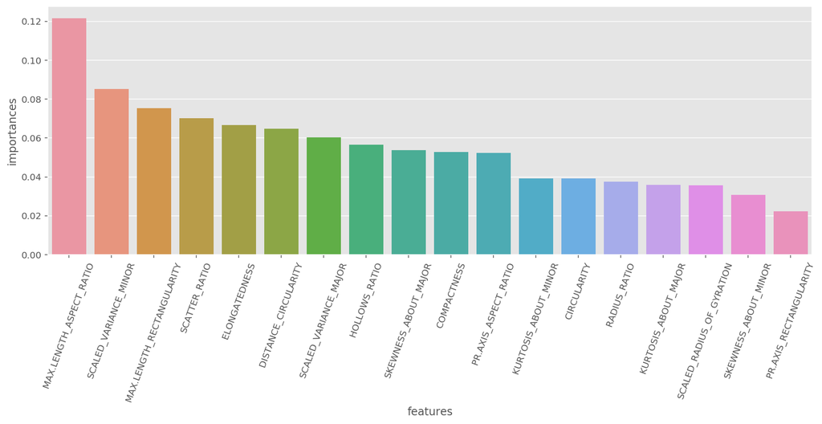

```python
plot_imp(Class_imp_for["Feature"], Class_imp_for["Class_Importance"], 'Random Forest')
```

**Model Evaluation Strategy**

Here, We train and tune the model on train data and test the model on test data. For hyperparameter tuning we used 5-fold cross validation for each model.

```python
from sklearn.model_selection import StratifiedKFold, GridSearchCV
from sklearn import metrics
from sklearn.metrics import precision_recall_curve, classification_report, confusion_matrix
from sklearn.metrics import accuracy_score, make_scorer, recall_score, precision_score, roc_auc_score

v_cross_val = StratifiedKFold(n_splits = 5, random_state = 999, shuffle = True)
```

Below, function is defined to extract and sends the best features to pipeline.

```python
from sklearn.pipeline import Pipeline
from sklearn.base import BaseEstimator, TransformerMixin

class FeatureExtractor(BaseEstimator, TransformerMixin):

    def __init__(self, n_features_ = 10):
        self.n_features_ = n_features_
        self.featureselection_indices_ = None

    def fit(self, X, y):
        from sklearn.ensemble import RandomForestClassifier
        from numpy import argsort
        RF_Model = RandomForestClassifier(n_estimators=100)
        RF_Model.fit(X, y)
        self.featureselection_indices_ = argsort(RF_Model.feature_importances_)[::-1][0:self.n_features_]
        return self

    def transform(self, X, y=None):
        return X[:, self.featureselection_indices_]
```

## Model Fitting & Tuning

### K-Nearest Neighbor (KNN)

Creating a Pipeline to extract best features using Random Forest classifier and performing hyperparameter tuning on KNN classifier using grid search with 5-fold cross validation.

```python
from sklearn.neighbors import KNeighborsClassifier

#building a pipeline for KNN
KNN_Pipeline = Pipeline(steps=[('rfi_fs', FeatureExtractor()),
                           ('knn', KNeighborsClassifier())])

#setting hyperparameters for tuning
KNN_Parameters = {'rfi_fs__n_features_': [10, 18, X_train.shape[1]],
                   'knn__n_neighbors': [1, 5, 10, 15],
                   'knn__p': [1, 2]}

#grid search for hyperparameters
KNN_GridSearch = GridSearchCV(estimator = KNN_Pipeline,
                           param_grid = KNN_Parameters,
                           cv = v_cross_val,
                           refit = True,
                           n_jobs = 2,
                           scoring='accuracy',
                           verbose = 1)
```

Fitting the train data on KNN classifier

```python
KNN_GridSearch.fit(X_train, y_train);
```

```
Fitting 5 folds for each of 24 candidates, totalling 120 fits
```

Getting best parameters for KNN classifier

```python
KNN_GridSearch.best_params_
```

```
{'knn__n_neighbors': 5, 'knn__p': 1, 'rfi_fs__n_features_': 18}
```

We got 5 Neighbors, 18 features and Manhattan distance 1 from the KNN model.

```python
KNN_GridSearch.best_score_
```

```
0.729682381427147
```

To check above values are best or not, we are displaying the top parameter combinations based on mean test score.

```python
KNN_Results = pd.DataFrame(KNN_GridSearch.cv_results_['params'])
KNN_Results['knn__p'] = KNN_Results['knn__p'].replace([1, 2], ["Manhattan", "Euclidean"])
KNN_Results['mean_AUC_score'] = KNN_GridSearch.cv_results_['mean_test_score']
KNN_Results.sort_values(by = ['mean_AUC_score'], ascending = False).head()
```

|  | knn__n_neighbors | knn__p | rfi_fs__n_features_ | mean_AUC_score |
| --- | --- | --- | --- | --- |
| 7 | 5 | Manhattan | 18 | 0.729682 |
| 8 | 5 | Manhattan | 18 | 0.729682 |
| 12 | 10 | Manhattan | 10 | 0.726307 |
| 18 | 15 | Manhattan | 10 | 0.718060 |
| 14 | 10 | Manhattan | 18 | 0.716180 |

Now checking the above parameter combinations visually for better understanding.

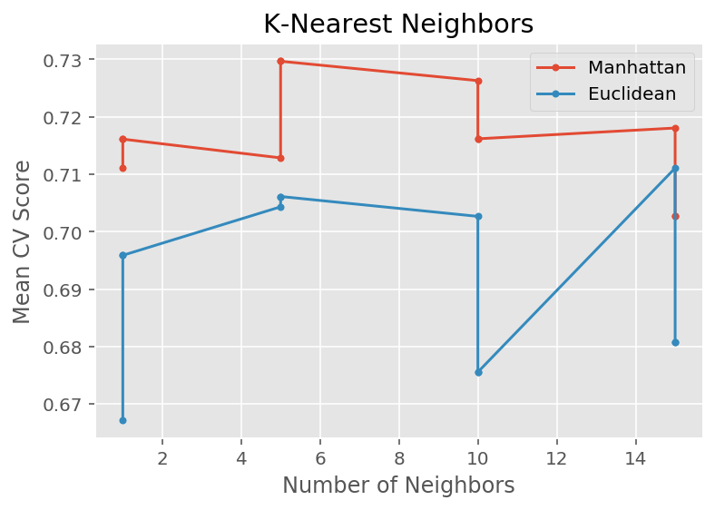

```python
%config InlineBackend.figure_format = 'retina'
plt.style.use("ggplot")

for i in ["Manhattan", "Euclidean"]:
    temp = KNN_Results[KNN_Results['knn__p'] == i]
    plt.plot(temp['knn__n_neighbors'], temp['mean_AUC_score'], marker = '.', label = i)

plt.legend()
plt.xlabel('Number of Neighbors')
plt.ylabel("Mean CV Score")
plt.title("K-Nearest Neighbors")
plt.show()
```

Therefore, the best parameters for tuning KNN are knn**n_neighbors = 5, knn**p = Manhattan distance and rfi_fs__n*features* = 18.

### Gaussian Naive Bayes (NB)

For implementing the Gaussian Naive Bayas, descriptive features in data should be in Gaussian distribution. To do so we used PowerTransformer() to transform the train data.

```python
from sklearn.preprocessing import PowerTransformer
X_train_transformed = PowerTransformer().fit_transform(X_train)
```

Now the data should be optimized. To do that we have to smoothen the data using var_smoothing. The default parameters of it is 10^(-9). Now the grid search is conducted in the logspace. In this we will take powers of 10 from 1 to -9.

```python
from sklearn.naive_bayes import GaussianNB

#building a pipeline for NB
NB_Pipeline = Pipeline([('rfi_fs', FeatureExtractor()),
                     ('nb', GaussianNB())])

#setting hyperparameters for tuning
NB_Parameters = {'rfi_fs__n_features_': [10, 15, X_train.shape[1]],
                  'nb__var_smoothing': np.logspace(1,-9, num=100)}

#grid search for hyperparameters
NB_GridSearch = GridSearchCV(estimator=NB_Pipeline,
                           param_grid=NB_Parameters,
                           cv=v_cross_val,
                           refit=True,
                           n_jobs=None,
                           pre_dispatch='2*n_jobs',
                           scoring='accuracy',
                           verbose=1)
```

Fitting the train data on Naive Bayes classifier

```python
NB_GridSearch.fit(X_train, y_train)
```

```
Fitting 5 folds for each of 300 candidates, totalling 1500 fits
```

```
GridSearchCV(cv=StratifiedKFold(n_splits=5, random_state=999, shuffle=True),
             estimator=Pipeline(steps=[('rfi_fs', FeatureExtractor()),
                                       ('nb', GaussianNB())]),
             param_grid={'nb__var_smoothing': array([1.00000000e+01, 7.92482898e+00, 6.28029144e+00, 4.97702356e+00,
       3.94420606e+00, 3.12571585e+00, 2.47707636e+00, 1.96304065e+00,
       1.55567614e+00, 1.23284674e+00, 9.7700995...
       8.30217568e-08, 6.57933225e-08, 5.21400829e-08, 4.13201240e-08,
       3.27454916e-08, 2.59502421e-08, 2.05651231e-08, 1.62975083e-08,
       1.29154967e-08, 1.02353102e-08, 8.11130831e-09, 6.42807312e-09,
       5.09413801e-09, 4.03701726e-09, 3.19926714e-09, 2.53536449e-09,
       2.00923300e-09, 1.59228279e-09, 1.26185688e-09, 1.00000000e-09]),
                         'rfi_fs__n_features_': [10, 15, 18]},
             scoring='accuracy', verbose=1)
```

Getting best parameters for Naive Bayes classifier

```python
NB_GridSearch.best_params_
```

```
{'nb__var_smoothing': 10.0, 'rfi_fs__n_features_': 10}
```

```python
NB_GridSearch.best_score_
```

```
0.5337986041874376
```

To check above values are best or not, we are displaying the top parameter combinations based on mean test score.

```python
NB_Results = pd.DataFrame(NB_GridSearch.cv_results_['params'])
NB_Results['mean_AUC_score'] = NB_GridSearch.cv_results_['mean_test_score']
NB_Results.sort_values(by = ['mean_AUC_score'], ascending = False).head()
```

|  | nb__var_smoothing | rfi_fs__n_features_ | mean_AUC_score |
| --- | --- | --- | --- |
| 0 | 10.000000 | 10 | 0.533799 |
| 91 | 0.009326 | 15 | 0.530380 |
| 88 | 0.011768 | 15 | 0.528685 |
| 97 | 0.005857 | 15 | 0.528685 |
| 145 | 0.000142 | 15 | 0.527019 |

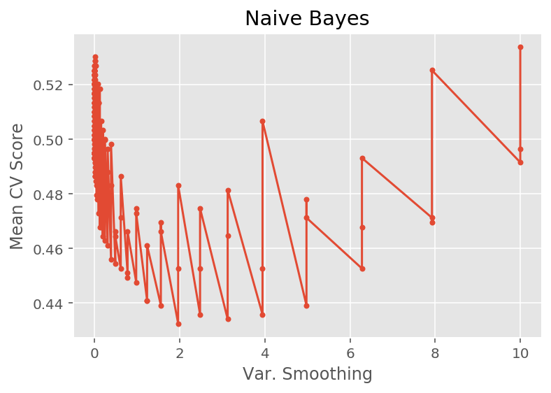

```python
plt.plot(NB_Results['nb__var_smoothing'], NB_Results['mean_AUC_score'], marker = '.')
plt.xlabel('Var. Smoothing')
plt.ylabel("Mean CV Score")
plt.title("Naive Bayes")
plt.show()
```

Therefore, the best parameters for tuning Naive Bayes are nb**var_smoothing = 10.0 and rfi_fs**n*features* = 10.

### SVC

Creating a Pipeline to extract best features using Random Forest classifier and performing hyperparameter tuning on SVC classifier using grid search with 5-fold cross validation.

```python
from sklearn.svm import SVC
```

```python
#building a pipeline for SVC
SVM_Pipeline  = Pipeline([('rfi_fs', FeatureExtractor()),
                     ('SVM', SVC())])

#setting hyperparameters for tuning
SVM_Parameters = {'rfi_fs__n_features_': [10, 18, X_train.shape[1]],
                  'SVM__C':[0.001,0.1,10,100,10e5], 'SVM__gamma':[0.1,0.01]}


#grid search for hyperparameters
SVM_GridSearch = GridSearchCV(estimator=SVM_Pipeline,
                           param_grid=SVM_Parameters,
                           cv=v_cross_val,
                           refit=True,
                           scoring = "accuracy",
                           pre_dispatch='2*n_jobs',
                           verbose=1)
```

Fitting the train data on SVM classifier

```python
SVM_GridSearch.fit(X_train, y_train)
```

```
Fitting 5 folds for each of 30 candidates, totalling 150 fits
```

[output not shown]

Getting best parameters for SVC classifier

```python
SVM_GridSearch.best_params_
```

```
{'SVM__C': 1000000.0, 'SVM__gamma': 0.01, 'rfi_fs__n_features_': 18}
```

We got 18 features, 1000000 regularisation parameter and 0.01 gamma.

```python
SVM_GridSearch.best_score_
```

```
0.8191853012391398
```

Below search results gives the best five scores based on different combinations of parameters.

```python
SVM_Results = pd.DataFrame(SVM_GridSearch.cv_results_['params'])
SVM_Results['mean_AUC_score'] = SVM_GridSearch.cv_results_['mean_test_score']
SVM_Results.sort_values(by = ['mean_AUC_score'], ascending = False).head()
```

[output not shown]

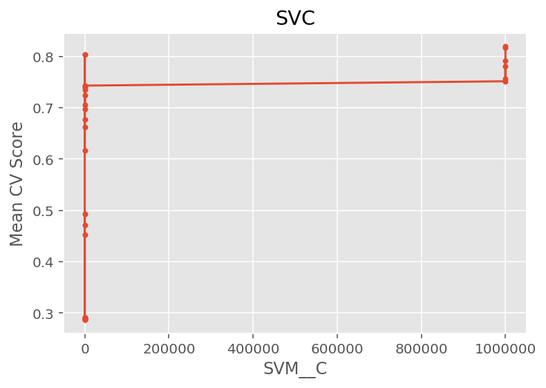

```python
plt.plot(SVM_Results['SVM__C'], SVM_Results['mean_AUC_score'], marker = '.')
plt.xlabel('SVM__C')
plt.ylabel("Mean CV Score")
plt.title("SVC")
plt.show()
```

### Decision Tree

Creating a Pipeline to extract best features using Random Forest classifier and performing hyperparameter tuning on Decision Tree classifier using grid search with 5-fold cross validation.

```python
from sklearn.tree import DecisionTreeClassifier
```

```python
#building a pipeline for DT
DT_Pipeline = Pipeline([('rfi_fs', FeatureExtractor()),
                    ('dt', DecisionTreeClassifier())])

#setting hyperparameters for tuning
DT_Parameters = {'rfi_fs__n_features_': [10, 15, X_train.shape[1]],
                'dt__criterion': ['gini', 'entropy'],
                 'dt__max_depth': [1, 2, 3, 4, 5, 6, 7, 8],
                 'dt__min_samples_split': [2, 3]}

#grid search for hyperparameters
DT_GridSearch = GridSearchCV(estimator=DT_Pipeline,
                     param_grid=DT_Parameters,
                     cv=v_cross_val,
                     refit=True,
                     verbose=1,
                     scoring='accuracy')
```

Fitting the train data on Decision Tree classifier

```python
DT_GridSearch.fit(X_train, y_train);
```

```
Fitting 5 folds for each of 96 candidates, totalling 480 fits
```

Getting best parameters for Decision Tree classifier

```python
DT_GridSearch.best_params_
```

```
{'dt__criterion': 'entropy',
 'dt__max_depth': 8,
 'dt__min_samples_split': 2,
 'rfi_fs__n_features_': 18}
```

We got entropy criterion with maximum depth of 8 and minimum sample split is of 2. Total features is 18.

```python
DT_GridSearch.best_score_
```

```
0.6909841902862841
```

Below search results gives the best five scores based on different combinations of parameters.

```python
DT_Results = pd.DataFrame(DT_GridSearch.cv_results_['params'])
DT_Results['mean_AUC_score'] = DT_GridSearch.cv_results_['mean_test_score']
DT_Results.sort_values(by = ['mean_AUC_score'], ascending = False).head()
```

|  | dt__criterion | dt__max_depth | dt__min_samples_split | rfi_fs__n_features_ | mean_AUC_score |
| --- | --- | --- | --- | --- | --- |
| 92 | entropy | 8 | 2 | 18 | 0.690984 |
| 87 | entropy | 7 | 3 | 10 | 0.690941 |
| 95 | entropy | 8 | 3 | 18 | 0.689332 |
| 36 | gini | 7 | 2 | 10 | 0.689090 |
| 91 | entropy | 8 | 2 | 15 | 0.687509 |

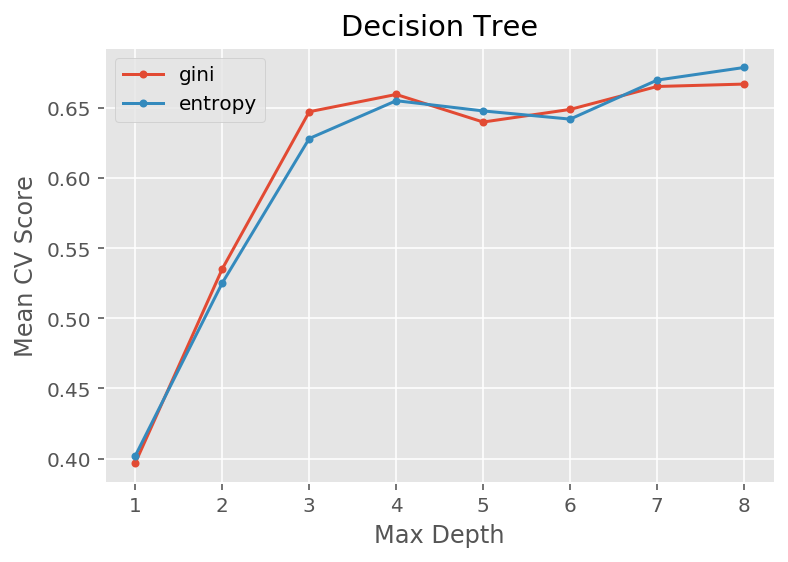

```python
for i in ['gini', 'entropy']:
    temp = DT_Results[DT_Results['dt__criterion'] == i]
    temp_average = temp.groupby('dt__max_depth').agg({'mean_AUC_score': 'mean'})
    plt.plot(temp_average, marker = '.', label = i)


plt.legend()
plt.xlabel('Max Depth')
plt.ylabel("Mean CV Score")
plt.title("Decision Tree")
plt.show()
```

### Logistic Regression

Creating a Pipeline to extract best features using Random Forest classifier and performing hyperparameter tuning on Logistic Regression classifier using grid search with 5-fold cross validation.

```python
from sklearn.linear_model import LogisticRegression
```

```python
#building a pipeline for Logistic Regression
LR_Pipeline = Pipeline([('rfi_fs', FeatureExtractor()),
                    ('logistic', LogisticRegression())])

#setting hyperparameters for tuning
LR_Parameters = {'rfi_fs__n_features_': [10, 15, X_train.shape[1]],
                  'logistic__C': np.logspace(-4, 4, 4)}

#grid search for hyperparameters
LR_GridSearch = GridSearchCV(estimator=LR_Pipeline,
                           param_grid=LR_Parameters,
                           cv=v_cross_val,
                           refit=True,
                           n_jobs=None,
                           pre_dispatch='2*n_jobs',
                           verbose=1)
```

Fitting the train data on Logistic Regression classifier

```python
LR_GridSearch.fit(X_train, y_train);
```

```
Fitting 5 folds for each of 12 candidates, totalling 60 fits
```

Getting best parameters for Logistic Regression classifier

```python
LR_GridSearch.best_params_
```

```
{'logistic__C': 10000.0, 'rfi_fs__n_features_': 18}
```

We got 18 features and 10000 inverse of regularization strength

```python
LR_GridSearch.best_score_
```

```
0.7786355220054124
```

Below search results gives the best five scores based on different combinations of parameters.

```python
LR_Results = pd.DataFrame(LR_GridSearch.cv_results_['params'])
LR_Results['mean_AUC_score'] = LR_GridSearch.cv_results_['mean_test_score']
LR_Results.sort_values(by = ['mean_AUC_score'], ascending = False).head()
```

|  | logistic__C | rfi_fs__n_features_ | mean_AUC_score |
| --- | --- | --- | --- |
| 11 | 10000.000000 | 18 | 0.778636 |
| 10 | 10000.000000 | 15 | 0.771913 |
| 8 | 21.544347 | 18 | 0.763424 |
| 7 | 21.544347 | 15 | 0.753311 |
| 6 | 21.544347 | 10 | 0.714528 |

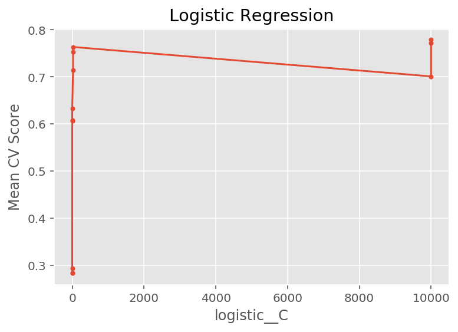

```python
plt.plot(LR_Results['logistic__C'], LR_Results['mean_AUC_score'], marker = '.')
plt.xlabel('logistic__C')
plt.ylabel("Mean CV Score")
plt.title("Logistic Regression")
plt.show()
```

## Model Comparison

To get the best performance model among the five models with best parameters, we are going to fit the test data on each model using 10-fold cross validation framework.

```python
from sklearn.model_selection import cross_val_score

cv_method_test = StratifiedKFold(n_splits = 10)
```

```python
cv_results_KNN = cross_val_score(estimator = KNN_GridSearch.best_estimator_,
                                 X = x_test,
                                 y = y_test,
                                 cv = cv_method_test)
cv_results_KNN.mean()
```

```
0.6463076923076922
```

```python
from sklearn.preprocessing import PowerTransformer

x_test_transformed = PowerTransformer().fit_transform(x_test)

cv_results_NB = cross_val_score(estimator = NB_GridSearch.best_estimator_,
                                 X = x_test_transformed,
                                 y = y_test,
                                 cv = cv_method_test)
cv_results_NB.mean()
```

```
0.43784615384615383
```

```python
cv_results_SVM = cross_val_score(estimator = SVM_GridSearch.best_estimator_,
                                 X = x_test,
                                 y = y_test,
                                 cv = cv_method_test)
cv_results_SVM.mean()
```

```
0.74
```

```python
cv_results_DT = cross_val_score(estimator = DT_GridSearch.best_estimator_,
                                 X = x_test,
                                 y = y_test,
                                 cv = cv_method_test)
cv_results_DT.mean()
```

```
0.5943076923076923
```

```python
cv_results_LR = cross_val_score(estimator = LR_GridSearch.best_estimator_,
                                 X = x_test,
                                 y = y_test,
                                 cv = cv_method_test)
cv_results_LR.mean()
```

```
0.755076923076923
```

Above mean values are the cross-validation scores which ran on test data. This validation is done with the same random state value for all the models. Due to this, the data split is same for all the models. Thereby, we used stats.ttest_rel function to determine the results have a statistically significant difference for each pair of models.

```python
from scipy import stats

stats.ttest_rel(cv_results_KNN, cv_results_NB)
```

```
Ttest_relResult(statistic=8.677957051604675, pvalue=1.1491648601336196e-05)
```

Test statistic, t= 8.68

Since p-value < 0.05, it is statistically significant with 95% confidence intervals.

```python
stats.ttest_rel(cv_results_KNN, cv_results_DT)
```

```
Ttest_relResult(statistic=1.521699381585692, pvalue=0.16241173608684376)
```

Test statistic, t = 1.522

Since p-value > 0.05, it is not statistically significant.

```python
stats.ttest_rel(cv_results_KNN, cv_results_SVM)
```

```
Ttest_relResult(statistic=-3.5033122295266677, pvalue=0.006688581220908659)
```

Test statistic, t= -3.503

Since p-value < 0.05, it is statistically significant with 95% confidence intervals. Negative t value suggest that SVM outperforms KNN.

```python
stats.ttest_rel(cv_results_SVM, cv_results_NB)
```

```
Ttest_relResult(statistic=8.789097279606043, pvalue=1.0361478231358256e-05)
```

Test statistic, t= 8.79

Since p-value < 0.05, it is statistically significant with 95% confidence intervals.

```python
stats.ttest_rel(cv_results_SVM, cv_results_DT)
```

```
Ttest_relResult(statistic=5.195938056278122, pvalue=0.0005671268002063575)
```

Test statistic, t= 5.196

Since p-value < 0.05, it is statistically significant with 95% confidence intervals.

```python
stats.ttest_rel(cv_results_SVM, cv_results_LR)
```

```
Ttest_relResult(statistic=-0.4490481142106219, pvalue=0.664014685434273)
```

Test statistic, t= -0.449

Since p-value > 0.05, it is statistically not significant.

But negative t value suggest that LR out performs better than SVM. This cannot be concluded as the test is not significant. Therefore, further analysis is needed.

To evaluate the best model among all we are using below metric scores,

```
• Accuracy
• Precision
• Recall
• F1 Score
```

```python
from sklearn.metrics import confusion_matrix, classification_report
```

```python
from sklearn import metrics

def run_classifier(clf, class_labels):

    y_pred = clf.predict(x_test)

    class_names = set(v_class[class_labels].values)

    print('Accuracy on Training data: ', round(clf.score(X_train, y_train), 2))

    print('Accuracy on Testing data: ', round(clf.score(x_test , y_test), 2))

    print('Recall value: ', round(metrics.recall_score(y_test, y_pred, average ='macro'), 2))

    print('Precision value: ', round(metrics.precision_score(y_test, y_pred, average ='macro'), 2))

    print('Classification Report: \n', classification_report(y_test, y_pred))
```

```python
run_classifier(KNN_GridSearch, 'Class')
```

```
Accuracy on Training data:  0.82
Accuracy on Testing data:  0.69
Recall value:  0.69
Precision value:  0.68
Classification Report:
               precision    recall  f1-score   support

         BUS       0.84      0.98      0.91        65
        OPEL       0.47      0.44      0.45        64
        SAAB       0.51      0.48      0.49        65
         VAN       0.89      0.85      0.87        60

    accuracy                           0.69       254
   macro avg       0.68      0.69      0.68       254
weighted avg       0.67      0.69      0.68       254
```

```python
y_pred = NB_GridSearch.predict(x_test_transformed)
X_train_transformed = PowerTransformer().fit_transform(X_train)

class_names = set(v_class['Class'].values)
print('Accuracy on Training data: ', round(NB_GridSearch.score(X_train_transformed, y_train), 2))
print('Accuracy on Testing data: ', round(NB_GridSearch.score(x_test_transformed , y_test), 2))
print('Recall value: ', round(metrics.recall_score(y_test, y_pred, average ='macro'), 2))
print('Precision value: ', round(metrics.precision_score(y_test, y_pred, average ='macro'), 2))
print('Classification Report: ', classification_report(y_test, y_pred))
```

```
Accuracy on Training data:  0.59
Accuracy on Testing data:  0.57
Recall value:  0.57
Precision value:  0.57
Classification Report:                precision    recall  f1-score   support

         BUS       0.66      0.83      0.73        65
        OPEL       0.51      0.42      0.46        64
        SAAB       0.59      0.20      0.30        65
         VAN       0.52      0.83      0.64        60

    accuracy                           0.57       254
   macro avg       0.57      0.57      0.53       254
weighted avg       0.57      0.57      0.53       254
```

```python
run_classifier(SVM_GridSearch, 'Class')
```

```
Accuracy on Training data:  0.96
Accuracy on Testing data:  0.82
Recall value:  0.82
Precision value:  0.82
Classification Report:
               precision    recall  f1-score   support

         BUS       0.88      1.00      0.94        65
        OPEL       0.71      0.72      0.71        64
        SAAB       0.78      0.66      0.72        65
         VAN       0.92      0.92      0.92        60

    accuracy                           0.82       254
   macro avg       0.82      0.82      0.82       254
weighted avg       0.82      0.82      0.82       254
```

```python
run_classifier(DT_GridSearch, 'Class')
```

```
Accuracy on Training data:  0.92
Accuracy on Testing data:  0.74
Recall value:  0.74
Precision value:  0.73
Classification Report:
               precision    recall  f1-score   support

         BUS       0.95      0.95      0.95        65
        OPEL       0.57      0.66      0.61        64
        SAAB       0.54      0.43      0.48        65
         VAN       0.87      0.92      0.89        60

    accuracy                           0.74       254
   macro avg       0.73      0.74      0.73       254
weighted avg       0.73      0.74      0.73       254
```

```python
run_classifier(LR_GridSearch, 'Class')
```

```
Accuracy on Training data:  0.82
Accuracy on Testing data:  0.82
Recall value:  0.83
Precision value:  0.82
Classification Report:
               precision    recall  f1-score   support

         BUS       0.94      1.00      0.97        65
        OPEL       0.73      0.67      0.70        64
        SAAB       0.68      0.66      0.67        65
         VAN       0.92      0.97      0.94        60

    accuracy                           0.82       254
   macro avg       0.82      0.83      0.82       254
weighted avg       0.82      0.82      0.82       254
```

Now we are moving on to Confusion Matrix.

```python
def plot_confusion_matrix(clf, y_test, classes,
                          title = 'Confusion matrix',
                          cmap = plt.cm.Blues, normalize=True):

    y_pred = clf.predict(x_test)

    cm = confusion_matrix(y_test, y_pred)
    np.set_printoptions(precision = 2)

    plt.figure()
    fig, ax = plt.subplots(figsize = (9, 7.2))
    plt.rcParams.update({'font.size': 15})
    plt.imshow(cm, interpolation = 'nearest', cmap = cmap)
    plt.title(title)
    tick_marks = np.arange(len(classes))
    plt.xticks(tick_marks, classes, rotation = 45)
    plt.yticks(tick_marks, classes)
    cm = cm.astype('float') / cm.sum(axis = 1)[:, np.newaxis]
    thresh = cm.max() / 2.
    for i, j in itertools.product(range(cm.shape[0]), range(cm.shape[1])):
        plt.text(j, i, "{0:.3f}".format(cm[i, j]),
                 horizontalalignment="center",
                 color="white" if cm[i, j] > thresh else "black")

    plt.tight_layout()
    plt.ylabel('True label')
    plt.xlabel('Predicted label')

    plt.show()

    classification_error_rate = 1.0 * sum(1 for (x, y) in zip(y_test, y_pred) if x != y) / len(list(y_test))
    print('Classification Error Rate: ', classification_error_rate)
```

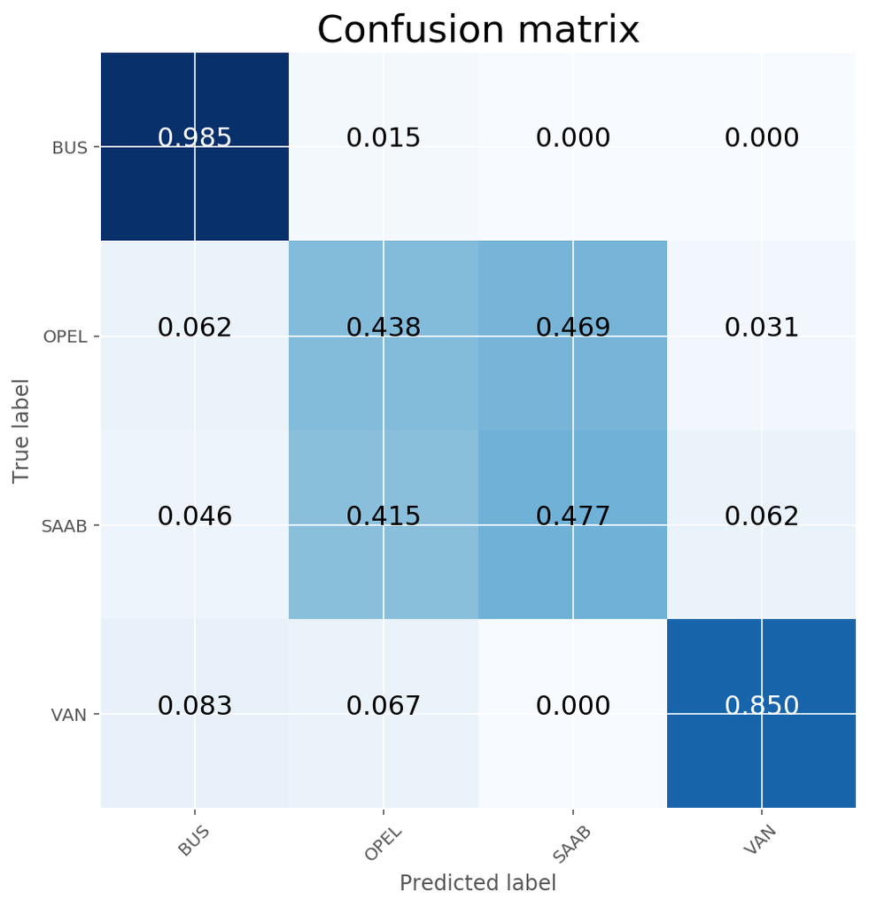

```
Classification Error Rate:  0.31496062992125984
```

```python
plot_confusion_matrix(KNN_GridSearch, y_test, np.unique(v_class))
```

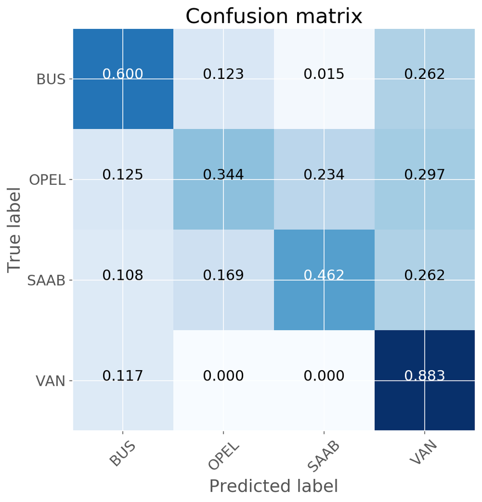

```
Classification Error Rate:  0.4330708661417323
```

```python
plot_confusion_matrix(NB_GridSearch, y_test, np.unique(v_class))
```

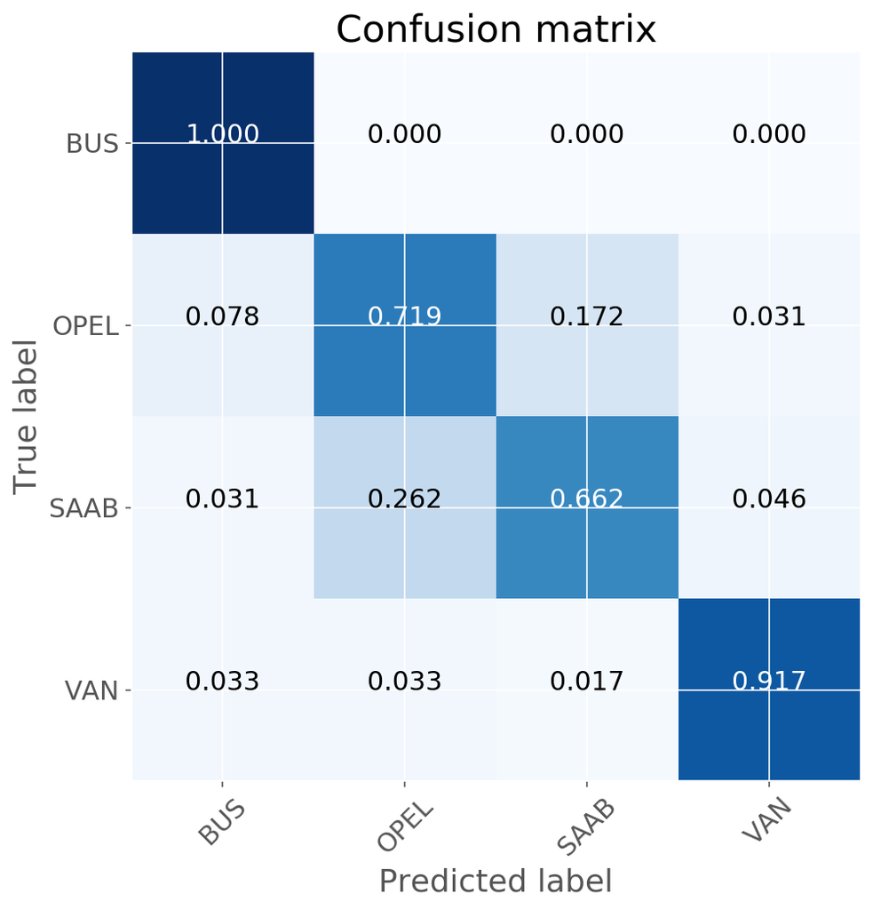

```
Classification Error Rate:  0.17716535433070865
```

```python
plot_confusion_matrix(SVM_GridSearch, y_test, np.unique(v_class))
```

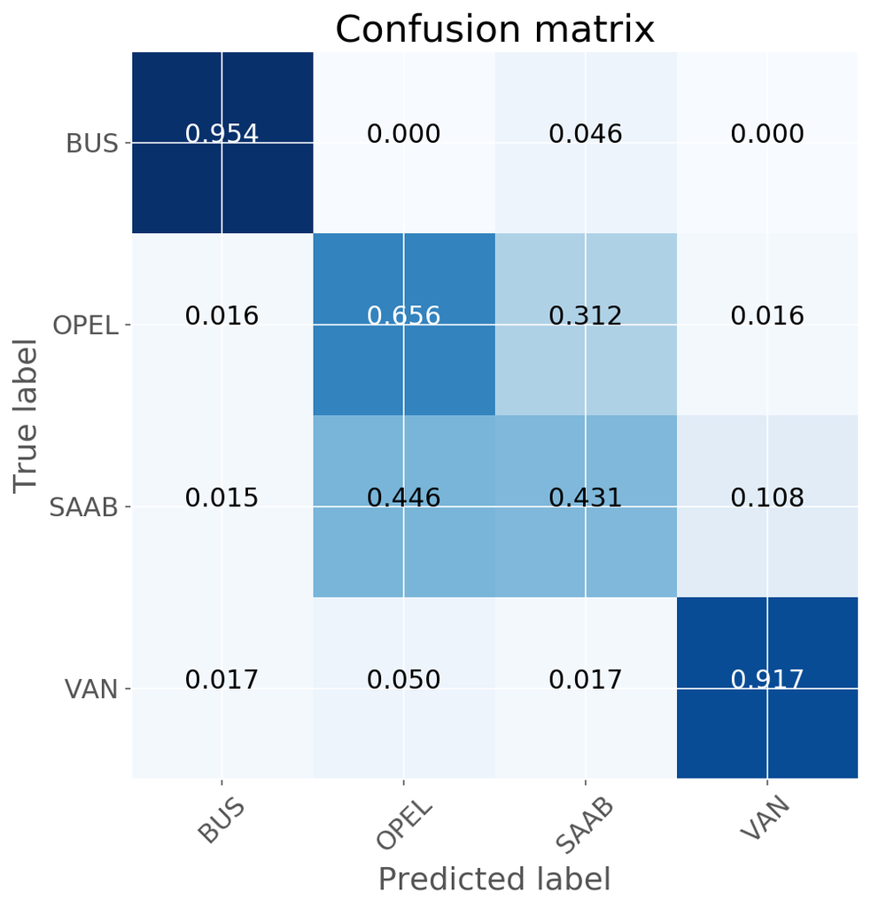

```
Classification Error Rate:  0.2637795275590551
```

```python
plot_confusion_matrix(DT_GridSearch, y_test, np.unique(v_class))
```

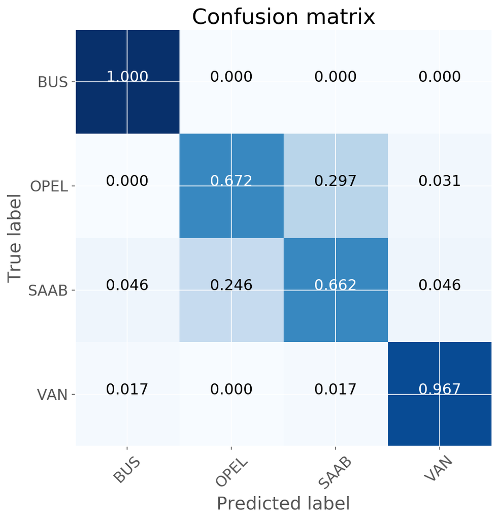

```
Classification Error Rate:  0.17716535433070865
```

```python
plot_confusion_matrix(LR_GridSearch, y_test, np.unique(v_class))
```

Let's check train and test accuracies of all models in one table for better understanding.

```python
Model_Accuracy = pd.DataFrame({'Model' : ['KNN', 'Naive_Bayes', 'SVM', 'Decision_Tree', 'Logistic Regression'],
                               'Train_Accuracy' : [round(KNN_GridSearch.score(X_train, y_train)*100, 2),
                                                   round(NB_GridSearch.score(X_train_transformed, y_train)*100, 2),
                                                   round(SVM_GridSearch.score(X_train, y_train)*100, 2),
                                                   round(DT_GridSearch.score(X_train, y_train)*100, 2),
                                                   round(LR_GridSearch.score(X_train, y_train)*100, 2)],
                               'Test_Accuracy' : [round(KNN_GridSearch.score(x_test, y_test)*100, 2),
                                                  round(NB_GridSearch.score(x_test_transformed, y_test)*100, 2),
                                                  round(SVM_GridSearch.score(x_test, y_test)*100, 2),
                                                  round(DT_GridSearch.score(x_test, y_test)*100, 2),
                                                  round(LR_GridSearch.score(X_train, y_train)*100, 2)]})

Model_Accuracy
```

|  | Model | Train_Accuracy | Test_Accuracy |
| --- | --- | --- | --- |
| 0 | KNN | 81.93 | 68.50 |
| 1 | Naive_Bayes | 58.78 | 56.69 |
| 2 | SVM | 95.78 | 82.28 |
| 3 | Decision_Tree | 91.55 | 73.62 |
| 4 | Logistic Regression | 82.26 | 82.26 |

# Critique & Limitations

We have noticed few limitations in our model building strategies,

1. We did analysis on the performance of models without interpreting the inputs as these are based on Black-Box approach. In future, we must follow different techniques in feature selection and in selection of hyperparameters.
2. Naïve Bayes classifier by default assumes all the features are independent to each other but in real predicting the actual values will get tougher as their will be dependent features.
3. In Naïve Bayes, we have transformed the train data to change the data into Gaussian Distribution, which intern may ignore few features. This may be the reason for the poor performance of Naïve Bayes. In future, this can be achieved by conducting different NB models on numerical and dummy descriptive features.
4. The comparatively less performance for decision tree might be due to the overfitting of the model.
5. Even though the test analysis suggested LR is out-performing than SVC due to test statistic. The statistically in significant p value resulted in the failure of the assumption requiring further analysis.

# Summary & Conclusions

## Project Summary

1. In phase 1, the data is initially loaded, and the data types are converted based on the requirement.
2. The data is then manipulated in case of any missing values, obvious errors / typos, white spaces and outliers. Then the respective case conversions are done.
3. The cleaned data is then visualised to perform any transformations or scaling if required.
4. On observing we came to know that there is some skewness in the data and is to be scalled.
5. We also observed some relationship(co-relations) between the features.
6. Then in phase 2, the cleaned data is scalled and data is prepared separately for training and testing.
7. The train data is used in fitting the model.
8. This is done through a pipeline, where in first step we get most important features from feature selection using Random Forrest and in second step different models are built.
9. Then the pipeline along with hyperparameters undergoes a Grid Search and gets the best parameters to fit the model.
10. The model is then fitted with the best parameters based on the best features generated by the RF selector.
11. These best parameters are then used to cross validate the data with 10 folds and respective scores are noted.
12. Since the validation is done with same portions of data (same random state) we performed a statistical relative test. Then concluded the best model among the 5.
13. For better analysis we also compared and analysed the classification metrics along with the confusion matrix.
14. Finally, the best model which predicts the class of the vehicle based on silhouette with high performance is chosen.
15. Then the limitations of our entire project are stated. This helps in enhancing our approach in future so that we can obtain more accurate results.

## Conclusions

# References

1. Putting it all together — scikit-learn 0.24.2 documentation. (2021). Retrieved 2 June 2021, from https://scikit-learn.org/stable/tutorial/statistical_inference/putting_together.html
2. Case Study: Predicting Income Status | www.featureranking.com. (2021). Retrieved 2 June 2021, from https://www.featureranking.com/tutorials/machine-learning-tutorials/case-study-predicting-income-status/
3. SK Part 3: Cross-Validation and Hyperparameter Tuning | www.featureranking.com. (2021). Retrieved 2 June 2021, from https://www.featureranking.com/tutorials/machine-learning-tutorials/sk-part-3-cross-validation-and-hyperparameter-tuning/
4. A Simple Example of Pipeline in Machine Learning with Scikit-learn. (2021). Retrieved 2 June 2021, from https://towardsdatascience.com/a-simple-example-of-pipeline-in-machine-learning-with-scikit-learn-e726ffbb6976
5. Phase 1 of our group (Group_99)